# Practical Machine Learning Course Project

Shane B. Bimeda

December 8, 2018

### Abstract

The report shows the analysis done to the **pmltrain.csv** and **pmltesting.csv** datasets to ultimately predict the manner in which the exercise was done by the subjects.  
The training data (**pmltraining.csv**) and testing data (**pmltesting.csv**) had undergone the same exploratory and data cleaning processes to make them fit for analysis.Training dataset was split into multiple train and test sets for use in the cross-validation processes during the model-building.  
In the model building, the author used **Recursive Partitioning Method** (**rpart**) in the **train()** function in the **caret package** and **Random Forest** from its eponymous package (**randomForest package**). The models were run on their respective test sets and their error and accuracy rates were calculated.

**Overall, the model built using the Random Forest method gave the highest accuracy metrics with its predictions as compared with the rpart model method.**

### Data

The large dataset came from the Weight Lifting Exercises Dataset *see References* of the Human Activity Recognition Research of Velloso et. al. (2013). Data was gathered through the following procedure stated in the cited study:

*“Six young health participants were asked to perform one set of 10 repetitions of the Unilateral Dumbbell Biceps Curl in five different fashions: exactly according to the specification (Class A), throwing the elbows to the front (Class B), lifting the dumbbell only halfway (Class C), lowering the dumbbell only halfway (Class D) and throwing the hips to the front (Class E).”*  
*“Class A corresponds to the specified execution of the exercise, while the other 4 classes correspond to common mistakes. Participants were supervised by an experienced weight lifter to make sure the execution complied to the manner they were supposed to simulate. The exercises were performed by six male participants aged between 20-28 years, with little weight lifting experience. We made sure that all participants could easily simulate the mistakes in a safe and controlled manner by using a relatively light dumbbell (1.25kg).”*

### Preliminaries (Exploratory and Data Cleaning)

#### This assumes that the directory was already set where the datasets are found.

```r
library(caret)
library(data.table)
library(randomForest)
set.seed(3433)

pmltraining <- read.csv("pml-training.csv")
pmltesting <- read.csv("pml-testing.csv")
```

#### subset the huge dataframe and make the needed train and test set from the training set for the cross validation

```r
training <- cbind(pmltraining[, 2], pmltraining[, 6:7], pmltraining[, 8:11], pmltraining[, 37:49],
                  pmltraining[, 60:68], pmltraining[, 84:86], pmltraining[, 102], pmltraining[, 113:124],
                  pmltraining[, 140], pmltraining[, 151:160])

inTrain <- createDataPartition(training$classe, p = 0.75,
                               list = FALSE)
train<- training[inTrain,]
trainTest<- training[-inTrain,]

testing <- cbind(pmltesting[, 2], pmltesting[, 6:7], pmltesting[, 8:11], pmltesting[, 37:49],
                 pmltesting[, 60:68], pmltesting[, 84:86], pmltesting[, 102], pmltesting[, 113:124],
                 pmltesting[, 140], pmltesting[, 151:160])
```

#### look at our datasets/explore again

```r
dim(train)
```

```
## [1] 14718    56
```

```r
dim(trainTest)
```

```
## [1] 4904   56
```

```r
dim(testing)
```

```
## [1] 20 56
```

### Training Proper

#### **rpart/Recursive Partitioning with preProcessing and Cross Validation**

```r
library(rpart);library(rattle); set.seed(143)
```

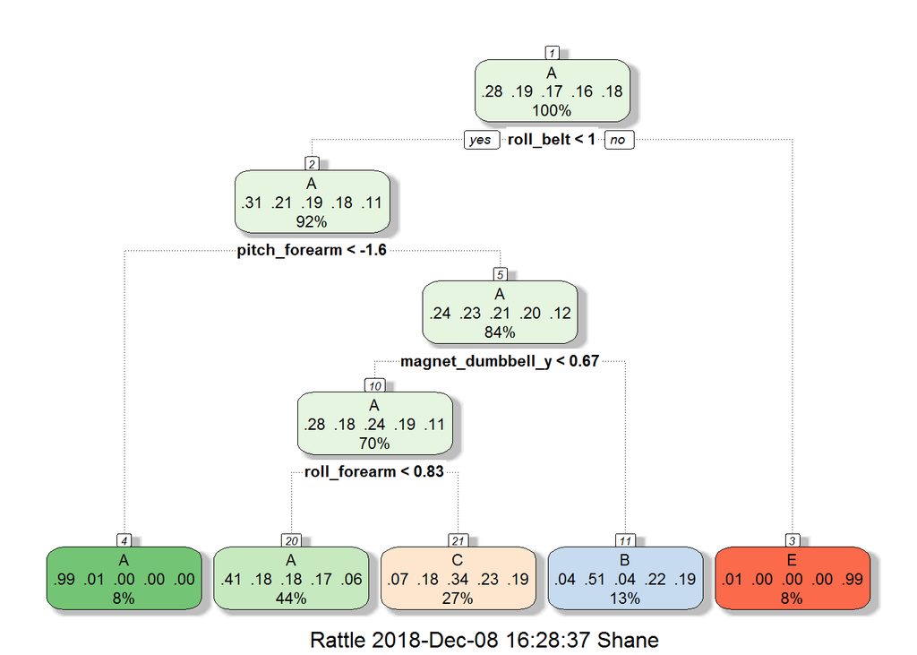

```r
modrtree2 <- train(x = train[, -56],
                  y = train$classe, method = "rpart",
                  preProcess = c("scale", "center"))

fancyRpartPlot(modrtree2$finalModel)
```

```r
predrtree2 <- predict(modrtree2, newdata = trainTest)

confusionMatrix(predrtree2, trainTest$classe)
```

```
## Confusion Matrix and Statistics
##
##           Reference
## Prediction    A    B    C    D    E
##          A 1269  415  412  366  135
##          B   12  296   25  135  124
##          C  112  238  418  303  242
##          D    0    0    0    0    0
##          E    2    0    0    0  400
##
## Overall Statistics
##
##                Accuracy : 0.4859
##                  95% CI : (0.4719, 0.5)
##     No Information Rate : 0.2845
##     P-Value [Acc > NIR] : < 2.2e-16
##
##                   Kappa : 0.3274
##  Mcnemar's Test P-Value : NA
##
## Statistics by Class:
##
##                      Class: A Class: B Class: C Class: D Class: E
## Sensitivity            0.9097  0.31191  0.48889   0.0000  0.44395
## Specificity            0.6215  0.92516  0.77896   1.0000  0.99950
## Pos Pred Value         0.4886  0.50000  0.31835      NaN  0.99502
## Neg Pred Value         0.9454  0.84856  0.87831   0.8361  0.88872
## Prevalence             0.2845  0.19352  0.17435   0.1639  0.18373
## Detection Rate         0.2588  0.06036  0.08524   0.0000  0.08157
## Detection Prevalence   0.5296  0.12072  0.26774   0.0000  0.08197
## Balanced Accuracy      0.7656  0.61853  0.63392   0.5000  0.72173
```

#### As we can see, the **Accuracy** of our rpart model is very low (**48.59%**). This means that the prediction of our model (on how well the person performs the exercise) is less likely to be true most of the time.

#### **Random Forest and Cross Validation**

#### **randomForest()**

```r
library(caret)
library(data.table)
library(randomForest)

set.seed(3433)
```

#### load the training and testing datasets

```r
pmltraining <- read.csv("pml-training.csv")
pmltesting <- read.csv("pml-testing.csv")
```

```r
pmltraining <- as.data.table(pmltraining)

pmltesting <- as.data.table(pmltesting)

training <- cbind(pmltraining[, 2], pmltraining[, 6:7], pmltraining[, 8:11], pmltraining[, 37:49],
                  pmltraining[, 60:68], pmltraining[, 84:86], pmltraining[, 102], pmltraining[, 113:124],
                  pmltraining[, 140], pmltraining[, 151:160])

inTrain <- createDataPartition(training$classe, p = 0.6,
                               list = FALSE)
train<- training[inTrain,]
test<- training[-inTrain,]

testing <- cbind(pmltesting[, 2], pmltesting[, 6:7], pmltesting[, 8:11], pmltesting[, 37:49],
                 pmltesting[, 60:68], pmltesting[, 84:86], pmltesting[, 102], pmltesting[, 113:124],
                 pmltesting[, 140], pmltesting[, 151:160])

dim(train); dim(test); dim(testing)
```

```
## [1] 11776    56
```

```
## [1] 7846   56
```

```
## [1] 20 56
```

```r
modrf <- randomForest(x = train[, -56],
                           y = train$classe)

predrf <- predict(modrf, test)

confusionMatrix(test$classe, predrf)
```

```
## Confusion Matrix and Statistics
##
##           Reference
## Prediction    A    B    C    D    E
##          A 2232    0    0    0    0
##          B    5 1513    0    0    0
##          C    0   14 1354    0    0
##          D    0    0   12 1273    1
##          E    0    0    0    3 1439
##
## Overall Statistics
##
##                Accuracy : 0.9955
##                  95% CI : (0.9938, 0.9969)
##     No Information Rate : 0.2851
##     P-Value [Acc > NIR] : < 2.2e-16
##
##                   Kappa : 0.9944
##  Mcnemar's Test P-Value : NA
##
## Statistics by Class:
##
##                      Class: A Class: B Class: C Class: D Class: E
## Sensitivity            0.9978   0.9908   0.9912   0.9976   0.9993
## Specificity            1.0000   0.9992   0.9978   0.9980   0.9995
## Pos Pred Value         1.0000   0.9967   0.9898   0.9899   0.9979
## Neg Pred Value         0.9991   0.9978   0.9981   0.9995   0.9998
## Prevalence             0.2851   0.1946   0.1741   0.1626   0.1835
## Detection Rate         0.2845   0.1928   0.1726   0.1622   0.1834
## Detection Prevalence   0.2845   0.1935   0.1744   0.1639   0.1838
## Balanced Accuracy      0.9989   0.9950   0.9945   0.9978   0.9994
```

### **Answers on the problem set**

#### Predictions of the random forest model on the **testing** data

#### Here we see that the 2nd variable (new_window) of **testing** data only has 1 factor level so we have to make it the same with the **train** data (with 2 factor levels) so that our model will work.

```r
str(testing)
```

```
## Classes 'data.table' and 'data.frame':   20 obs. of  56 variables:
##  $ user_name           : Factor w/ 6 levels "adelmo","carlitos",..: 6 5 5 1 4 5 5 5 2 3 ...
##  $ new_window          : Factor w/ 1 level "no": 1 1 1 1 1 1 1 1 1 1 ...
##  $ num_window          : int  74 431 439 194 235 504 485 440 323 664 ...
##  $ roll_belt           : num  123 1.02 0.87 125 1.35 -5.92 1.2 0.43 0.93 114 ...
##  $ pitch_belt          : num  27 4.87 1.82 -41.6 3.33 1.59 4.44 4.15 6.72 22.4 ...
##  $ yaw_belt            : num  -4.75 -88.9 -88.5 162 -88.6 -87.7 -87.3 -88.5 -93.7 -13.1 ...
##  $ total_accel_belt    : int  20 4 5 17 3 4 4 4 4 18 ...
##  $ gyros_belt_x        : num  -0.5 -0.06 0.05 0.11 0.03 0.1 -0.06 -0.18 0.1 0.14 ...
##  $ gyros_belt_y        : num  -0.02 -0.02 0.02 0.11 0.02 0.05 0 -0.02 0 0.11 ...
##  $ gyros_belt_z        : num  -0.46 -0.07 0.03 -0.16 0 -0.13 0 -0.03 -0.02 -0.16 ...
##  $ accel_belt_x        : int  -38 -13 1 46 -8 -11 -14 -10 -15 -25 ...
##  $ accel_belt_y        : int  69 11 -1 45 4 -16 2 -2 1 63 ...
##  $ accel_belt_z        : int  -179 39 49 -156 27 38 35 42 32 -158 ...
##  $ magnet_belt_x       : int  -13 43 29 169 33 31 50 39 -6 10 ...
```

[output cut: 43 more lines]

```r
colnames_train <- colnames(train)
colnames_testing <- colnames(testing)

levels(testing$new_window) <- levels(train$new_window)
all.equal(colnames_train[1:length(colnames_train) -1], colnames_testing[1:length(colnames_testing)-1])
```

```
## [1] TRUE
```

#### This is very important to be TRUE or our model will not work on this testing dataset.

#### **Finally, here are my answers:**

```r
predTesting <- predict(modrf, testing)

predTesting
```

```
##  1  2  3  4  5  6  7  8  9 10 11 12 13 14 15 16 17 18 19 20
##  B  A  B  A  A  E  D  B  A  A  B  C  B  A  E  E  A  B  B  B
## Levels: A B C D E
```

### Reference

Velloso, E.; Bulling, A.; Gellersen, H.; Ugulino, W.; Fuks, H. Qualitative Activity Recognition of Weight Lifting Exercises . Proceedings of 4th International Conference in Cooperation with SIGCHI (Augmented Human ’13) . Stuttgart, Germany: ACM SIGCHI, 2013.